# Install & Import Libraries

```python
!pip install -q scikit-learn pandas numpy matplotlib seaborn

import numpy as np
import pandas as pd
import matplotlib.pyplot as plt
import seaborn as sns
import warnings
warnings.filterwarnings('ignore')

from sklearn.preprocessing import StandardScaler
from sklearn.model_selection import train_test_split, StratifiedKFold, cross_validate, RandomizedSearchCV
from sklearn.linear_model import LogisticRegression
from sklearn.ensemble import RandomForestClassifier
from sklearn.tree import DecisionTreeClassifier
from sklearn.metrics import (
    classification_report, confusion_matrix, ConfusionMatrixDisplay,
    roc_auc_score, average_precision_score,
    precision_recall_curve, roc_curve, f1_score
)
from sklearn.inspection import permutation_importance

RANDOM_STATE = 42
np.random.seed(RANDOM_STATE)

print("All libraries imported successfully.")
```

```
All libraries imported successfully.
```

**Problem Statement**:

# M505 Intro to AI and Machine Learning — Individual Project (Sachin - GH1045604)

## Credit Card Fraud Detection: An End-to-End Machine Learning Pipeline

**Gisma University of Applied Sciences | School of Computer Science**

## 1. Problem Statement

### 1.1 Business Problem

The financial sector is one of the most affected by the credit card fraud, and it is one of the most prevalent forms of fraud. According to industry estimates, losses from card fraud worldwide are more than $30 billion per year, resulting in financial loss to both cardholders and issuing banks. Each transaction that is not detected by the merchant is a chargeback, a lost reputation and a loss of customer trust. An important need for any financial institution is to be able to automatically **detect fraudulent transactions**. The challenge is based on a basic trade-off:

- When the bank loses a customer because of a fraud (false negative), it has a loss and damages customer relationship. Flagging a legitimate transaction (false positive): The customer is inconvenienced and they may go to a competitor. The aim is to maximise the fraud detection, while minimising the impact on legitimate customers, which is a classic precision–recall trade-off.

### 1.2 Why This Problem Matters

- Financial impact: Undetected fraud has a financial impact, which is a decrease in revenue. It's very costly and impractical to manually review all flagged transactions. Irrespective of these, proactive and accurate fraud detection helps customers gain trust in the security of the bank. Regulatory pressure: Regulations, like PSD2 in Europe, impose the obligation for financial institutions to prove that they can support effective fraud defence. Penalties and enforcement are imposed for non-compliance. A well-trained ML model can process millions of transactions in milliseconds as opposed to human analysts.

### 1.3 Data Collection Strategy

In a real-world scenario, transaction data would actually be sent from the payment gateway in real-time. The metadata for each record would be: transaction value, merchant category code, date, cardholder location, device fingerprint, and the velocity of transactions over a period of time.

For this project, we use a publicly available benchmark dataset:

**Dataset:** Creditcard.csv

**URL:** https://www.kaggle.com/datasets/mlg-ulb/creditcardfraud

This source consists of 284,807 credit card transactions of Europeans during 2 days in September 2013. Features V1–V28 are principal components (PCA) of the original transaction features that are used to help maintain cardholder privacy. The non-transformed features are: Time, Amount and Class (0 = legitimate, 1 = fraud). Only 492 of 284,807 transactions are fraudulent (~0.17%).

### 1.4 Machine Learning Formulation

- Output (y): Binary label — 0 (legitimate) or 1 (fraudulent)

The main problem is the extreme class imbalance (~0.17% fraud). Standard accuracy is a bogus one: a model that always gives 'legitimate' scores, and zero detection of fraud 99.83% accuracy. F1-Score and Area under the Precision-Recall Curve (AUPRC) are thus used as primary evaluation metrics.

**Load Dataset**

```python
df = pd.read_csv('creditcard.csv')
```

```python
df.head()
```

|  | Time | V1 | V2 | V3 | V4 | V5 | V6 | V7 | V8 | V9 | ... | V21 | V22 | V23 | V24 | V25 | V26 | V27 | V28 | Amount | Class |
| --- | --- | --- | --- | --- | --- | --- | --- | --- | --- | --- | --- | --- | --- | --- | --- | --- | --- | --- | --- | --- | --- |
| 0 | 0.0 | -1.359807 | -0.072781 | 2.536347 | 1.378155 | -0.338321 | 0.462388 | 0.239599 | 0.098698 | 0.363787 | ... | -0.018307 | 0.277838 | -0.110474 | 0.066928 | 0.128539 | -0.189115 | 0.133558 | -0.021053 | 149.62 | 0 |
| 1 | 0.0 | 1.191857 | 0.266151 | 0.166480 | 0.448154 | 0.060018 | -0.082361 | -0.078803 | 0.085102 | -0.255425 | ... | -0.225775 | -0.638672 | 0.101288 | -0.339846 | 0.167170 | 0.125895 | -0.008983 | 0.014724 | 2.69 | 0 |
| 2 | 1.0 | -1.358354 | -1.340163 | 1.773209 | 0.379780 | -0.503198 | 1.800499 | 0.791461 | 0.247676 | -1.514654 | ... | 0.247998 | 0.771679 | 0.909412 | -0.689281 | -0.327642 | -0.139097 | -0.055353 | -0.059752 | 378.66 | 0 |
| 3 | 1.0 | -0.966272 | -0.185226 | 1.792993 | -0.863291 | -0.010309 | 1.247203 | 0.237609 | 0.377436 | -1.387024 | ... | -0.108300 | 0.005274 | -0.190321 | -1.175575 | 0.647376 | -0.221929 | 0.062723 | 0.061458 | 123.50 | 0 |
| 4 | 2.0 | -1.158233 | 0.877737 | 1.548718 | 0.403034 | -0.407193 | 0.095921 | 0.592941 | -0.270533 | 0.817739 | ... | -0.009431 | 0.798278 | -0.137458 | 0.141267 | -0.206010 | 0.502292 | 0.219422 | 0.215153 | 69.99 | 0 |

5 rows × 31 columns

## Data Exploration:

**Dataset Overview**

**Dataset Info**

```python
df.info()
```

```
<class 'pandas.core.frame.DataFrame'>
RangeIndex: 284807 entries, 0 to 284806
Data columns (total 31 columns):
 #   Column  Non-Null Count   Dtype
---  ------  --------------   -----
 0   Time    284807 non-null  float64
 1   V1      284807 non-null  float64
 2   V2      284807 non-null  float64
 3   V3      284807 non-null  float64
 4   V4      284807 non-null  float64
 5   V5      284807 non-null  float64
 6   V6      284807 non-null  float64
 7   V7      284807 non-null  float64
 8   V8      284807 non-null  float64
 9   V9      284807 non-null  float64
```

[output cut: 23 more lines]

**Descriptive Statistics**

```python
df.describe().T.style.background_gradient(cmap='coolwarm', subset=['mean', 'std'])
```

|  | count | mean | std | min | 25% | 50% | 75% | max |
| --- | --- | --- | --- | --- | --- | --- | --- | --- |
| Time | 284807.000000 | 94813.859575 | 47488.145955 | 0.000000 | 54201.500000 | 84692.000000 | 139320.500000 | 172792.000000 |
| V1 | 284807.000000 | 0.000000 | 1.958696 | -56.407510 | -0.920373 | 0.018109 | 1.315642 | 2.454930 |
| V2 | 284807.000000 | 0.000000 | 1.651309 | -72.715728 | -0.598550 | 0.065486 | 0.803724 | 22.057729 |
| V3 | 284807.000000 | -0.000000 | 1.516255 | -48.325589 | -0.890365 | 0.179846 | 1.027196 | 9.382558 |
| V4 | 284807.000000 | 0.000000 | 1.415869 | -5.683171 | -0.848640 | -0.019847 | 0.743341 | 16.875344 |
| V5 | 284807.000000 | 0.000000 | 1.380247 | -113.743307 | -0.691597 | -0.054336 | 0.611926 | 34.801666 |
| V6 | 284807.000000 | 0.000000 | 1.332271 | -26.160506 | -0.768296 | -0.274187 | 0.398565 | 73.301626 |
| V7 | 284807.000000 | -0.000000 | 1.237094 | -43.557242 | -0.554076 | 0.040103 | 0.570436 | 120.589494 |
| V8 | 284807.000000 | 0.000000 | 1.194353 | -73.216718 | -0.208630 | 0.022358 | 0.327346 | 20.007208 |
| V9 | 284807.000000 | -0.000000 | 1.098632 | -13.434066 | -0.643098 | -0.051429 | 0.597139 | 15.594995 |
| V10 | 284807.000000 | 0.000000 | 1.088850 | -24.588262 | -0.535426 | -0.092917 | 0.453923 | 23.745136 |
| V11 | 284807.000000 | 0.000000 | 1.020713 | -4.797473 | -0.762494 | -0.032757 | 0.739593 | 12.018913 |
| V12 | 284807.000000 | -0.000000 | 0.999201 | -18.683715 | -0.405571 | 0.140033 | 0.618238 | 7.848392 |
| V13 | 284807.000000 | 0.000000 | 0.995274 | -5.791881 | -0.648539 | -0.013568 | 0.662505 | 7.126883 |
| V14 | 284807.000000 | 0.000000 | 0.958596 | -19.214325 | -0.425574 | 0.050601 | 0.493150 | 10.526766 |
| V15 | 284807.000000 | 0.000000 | 0.915316 | -4.498945 | -0.582884 | 0.048072 | 0.648821 | 8.877742 |
| V16 | 284807.000000 | 0.000000 | 0.876253 | -14.129855 | -0.468037 | 0.066413 | 0.523296 | 17.315112 |
| V17 | 284807.000000 | -0.000000 | 0.849337 | -25.162799 | -0.483748 | -0.065676 | 0.399675 | 9.253526 |
| V18 | 284807.000000 | 0.000000 | 0.838176 | -9.498746 | -0.498850 | -0.003636 | 0.500807 | 5.041069 |
| V19 | 284807.000000 | 0.000000 | 0.814041 | -7.213527 | -0.456299 | 0.003735 | 0.458949 | 5.591971 |
| V20 | 284807.000000 | 0.000000 | 0.770925 | -54.497720 | -0.211721 | -0.062481 | 0.133041 | 39.420904 |
| V21 | 284807.000000 | 0.000000 | 0.734524 | -34.830382 | -0.228395 | -0.029450 | 0.186377 | 27.202839 |
| V22 | 284807.000000 | -0.000000 | 0.725702 | -10.933144 | -0.542350 | 0.006782 | 0.528554 | 10.503090 |
| V23 | 284807.000000 | 0.000000 | 0.624460 | -44.807735 | -0.161846 | -0.011193 | 0.147642 | 22.528412 |
| V24 | 284807.000000 | 0.000000 | 0.605647 | -2.836627 | -0.354586 | 0.040976 | 0.439527 | 4.584549 |
| V25 | 284807.000000 | 0.000000 | 0.521278 | -10.295397 | -0.317145 | 0.016594 | 0.350716 | 7.519589 |
| V26 | 284807.000000 | 0.000000 | 0.482227 | -2.604551 | -0.326984 | -0.052139 | 0.240952 | 3.517346 |
| V27 | 284807.000000 | -0.000000 | 0.403632 | -22.565679 | -0.070840 | 0.001342 | 0.091045 | 31.612198 |
| V28 | 284807.000000 | -0.000000 | 0.330083 | -15.430084 | -0.052960 | 0.011244 | 0.078280 | 33.847808 |
| Amount | 284807.000000 | 88.349619 | 250.120109 | 0.000000 | 5.600000 | 22.000000 | 77.165000 | 25691.160000 |
| Class | 284807.000000 | 0.001727 | 0.041527 | 0.000000 | 0.000000 | 0.000000 | 0.000000 | 1.000000 |

**Data Quality Assessment**

**Missing Values & Duplicates**

```python
missing = df.isnull().sum()
total_missing = missing.sum()

if total_missing == 0:
  print("No missing value detected. The Dataset is complete")
else:
  print(f"Missing values:\n{missing[missing > 0]}")

n_dupes = df.duplicated().sum()
print(f"\nDuplicate rows: {n_dupes:,}")
if n_dupes > 0:
    print("These will be removed during preprocessing to avoid training bias.")
```

```
No missing value detected. The Dataset is complete

Duplicate rows: 1,081
These will be removed during preprocessing to avoid training bias.
```

## Class Imbalance

**Class Distribution Charts**

```
Class Distribution
  Legitimate (0):  284,315  (99.8273%)
  Fraudulent (1):      492  (0.1727%)
  Imbalance ratio: ~577:1
```

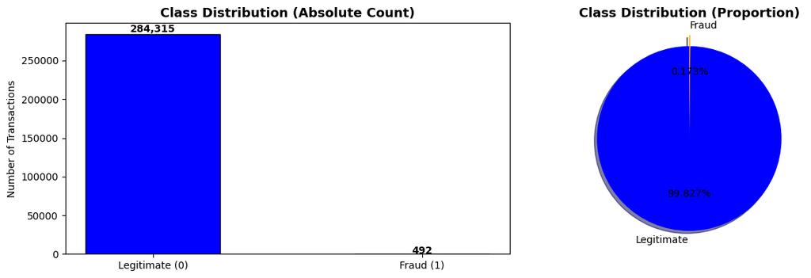

```python
class_counts = df['Class'].value_counts()
class_pct    = df['Class'].value_counts(normalize=True) * 100

print("Class Distribution")
print(f"  Legitimate (0): {class_counts[0]:>8,}  ({class_pct[0]:.4f}%)")
print(f"  Fraudulent (1): {class_counts[1]:>8,}  ({class_pct[1]:.4f}%)")
print(f"  Imbalance ratio: ~{int(class_counts[0]/class_counts[1])}:1")

fig, axes = plt.subplots(1, 2, figsize=(13, 4))

bars = axes[0].bar(['Legitimate (0)', 'Fraud (1)'], class_counts.values,
                   color=['blue', 'orange'], edgecolor='black', width=0.5)

axes[0].set_title('Class Distribution (Absolute Count)', fontsize=13, fontweight='bold')
axes[0].set_ylabel('Number of Transactions')

for bar, val in zip(bars, class_counts.values):
    axes[0].text(bar.get_x() + bar.get_width()/2, bar.get_height() * 1.01,
                 f'{val:,}', ha='center', fontweight='bold')

axes[1].pie(class_counts.values, labels=['Legitimate', 'Fraud'],
            autopct='%1.3f%%', colors=['blue', 'orange'],
            startangle=90, explode=(0, 0.12), shadow=True)
axes[1].set_title('Class Distribution (Proportion)', fontsize=13, fontweight='bold')

plt.tight_layout()
plt.show()
```

**Imbalance Explanation**:

**Imbalance Discussion:**

Fraudulent transactions represent only ~0.17% of all records — a ratio of roughly 578:1. This is the central modelling challenge:

| Strategy | Decision | Justification |
| --- | --- | --- |
| Accuracy metric | Rejected | A model always predicting 'legit' scores 99.83% — useless |
| Undersampling | Rejected | Discards 99%+ of legitimate data — information loss |
| Oversampling (SMOTE) | Not required | `class_weight` achieves same effect without synthetic data |
| `class_weight='balanced'` | **Adopted** | Penalises fraud misclassification proportionally to its rarity |
| F1 / AUPRC metrics | **Adopted** | Correctly evaluate performance on imbalanced classes |

**Amount Distribution by Class**

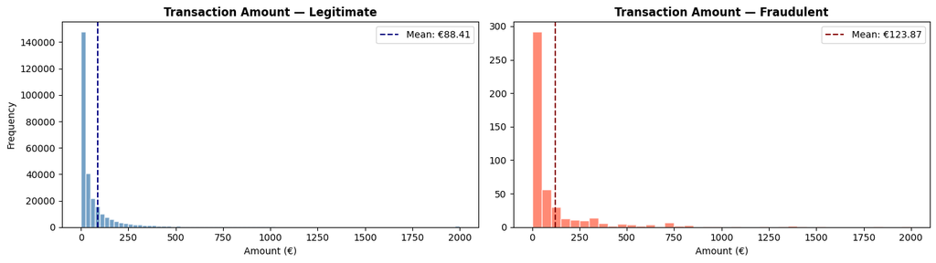

```
Legitimate — Mean: €88.41, Median: €22.00
Fraudulent — Mean: €123.87, Median: €9.82
```

```python
fraud = df[df['Class'] == 1]
legit = df[df['Class'] == 0]

fig, axes = plt.subplots(1, 2, figsize=(14, 4))

axes[0].hist(legit['Amount'].clip(upper=2000), bins=80,
             color='steelblue', alpha=0.75, edgecolor='white')
axes[0].set_title('Transaction Amount — Legitimate', fontsize=12, fontweight='bold')
axes[0].set_xlabel('Amount (€)')
axes[0].set_ylabel('Frequency')
axes[0].axvline(legit['Amount'].mean(), color='navy', linestyle='--',
                label=f"Mean: €{legit['Amount'].mean():.2f}")
axes[0].legend()

axes[1].hist(fraud['Amount'].clip(upper=2000), bins=40,
             color='tomato', alpha=0.75, edgecolor='white')
axes[1].set_title('Transaction Amount — Fraudulent', fontsize=12, fontweight='bold')
axes[1].set_xlabel('Amount (€)')
axes[1].axvline(fraud['Amount'].mean(), color='darkred', linestyle='--',
                label=f"Mean: €{fraud['Amount'].mean():.2f}")
axes[1].legend()

plt.tight_layout()
plt.show()

print(f"Legitimate — Mean: €{legit['Amount'].mean():.2f}, Median: €{legit['Amount'].median():.2f}")
print(f"Fraudulent — Mean: €{fraud['Amount'].mean():.2f}, Median: €{fraud['Amount'].median():.2f}")
```

**Feature Correlation with Fraud**

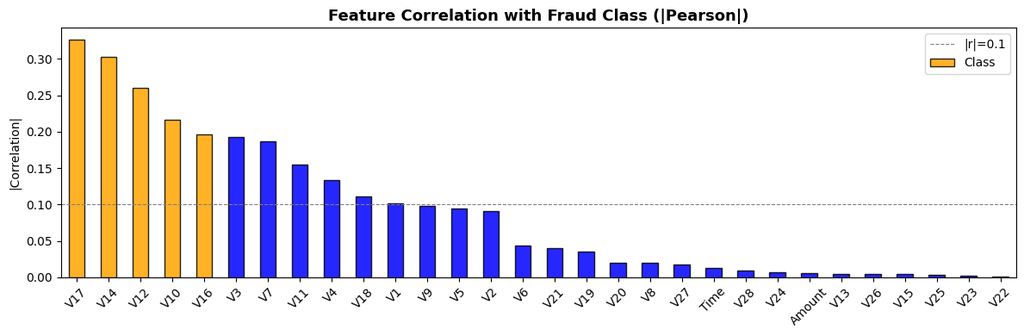

```
Top 5 features most correlated with fraud:
V17    0.326481
V14    0.302544
V12    0.260593
V10    0.216883
V16    0.196539
```

```python
correlations = df.corr()['Class'].drop('Class').abs().sort_values(ascending=False)

plt.figure(figsize=(12, 4))
colors = ['Orange' if i < 5 else 'blue' for i in range(len(correlations))]

correlations.plot(kind='bar', color=colors, edgecolor='black', alpha=0.85)
plt.title('Feature Correlation with Fraud Class (|Pearson|)', fontsize=13, fontweight='bold')
plt.ylabel('|Correlation|')
plt.xticks(rotation=45)

plt.axhline(0.1, color='gray', linestyle='--', linewidth=0.8, label='|r|=0.1')
plt.legend()
plt.tight_layout()
plt.show()

print("Top 5 features most correlated with fraud:")
print(correlations.head(5).to_string())
```

**BoxPlots of Top Features**

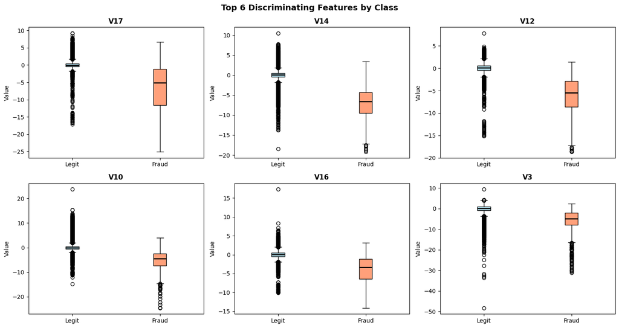

```python
top_features = correlations.head(6).index.tolist()

fig, axes = plt.subplots(2, 3, figsize=(15, 8))
axes = axes.flatten()

for i, feat in enumerate(top_features):
    bp = axes[i].boxplot([legit[feat].values, fraud[feat].values],
                         labels=['Legit', 'Fraud'],
                         patch_artist=True,
                         medianprops=dict(color='black', linewidth=2))
    bp['boxes'][0].set_facecolor('lightblue')
    bp['boxes'][1].set_facecolor('lightsalmon')
    axes[i].set_title(f'{feat}', fontsize=12, fontweight='bold')
    axes[i].set_ylabel('Value')

plt.suptitle('Top 6 Discriminating Features by Class', fontsize=14, fontweight='bold')
plt.tight_layout()
plt.show()
```

# Preprocessing:

**Data Preprocessing & feature Engineering**

**Remove Duplicates**

```python
initial_rows = len(df)
df = df.drop_duplicates()
removed = initial_rows - len(df)
print(f"Removed {removed:,} duplicate rows. Remaining: {len(df):,}")
```

```
Removed 1,081 duplicate rows. Remaining: 283,726
```

**Feature Engineering**

```
Engineered features added:
  'Hour'       — hour of day derived from Time
  'Log_Amount' — log1p transformation of Amount
```

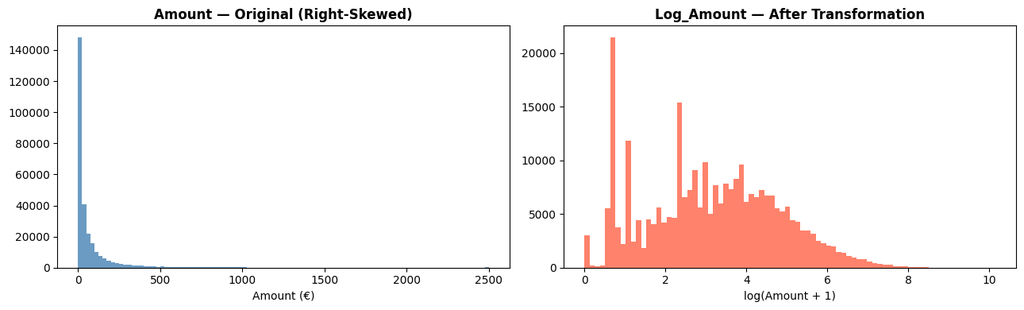

```python
df['Hour'] = (df['Time'] // 3600) % 24
df['Log_Amount'] = np.log1p(df['Amount'])

print("Engineered features added:")
print("  'Hour'       — hour of day derived from Time")
print("  'Log_Amount' — log1p transformation of Amount")

fig, axes = plt.subplots(1, 2, figsize=(13, 4))

axes[0].hist(df['Amount'].clip(upper=2500), bins=100, color='steelblue', alpha=0.8)
axes[0].set_title('Amount — Original (Right-Skewed)', fontsize=12, fontweight='bold')
axes[0].set_xlabel('Amount (€)')

axes[1].hist(df['Log_Amount'], bins=80, color='tomato', alpha=0.8)
axes[1].set_title('Log_Amount — After Transformation', fontsize=12, fontweight='bold')
axes[1].set_xlabel('log(Amount + 1)')

plt.tight_layout()
plt.show()
```

**Define X and Y**

```python
X = df.drop(columns=['Time', 'Amount', 'Class'])
y = df['Class']

print(f"Feature matrix (X): {X.shape[0]:,} samples x {X.shape[1]} features")
print(f"Target vector  (y): {y.shape[0]:,} samples")
print(f"\nAll features: {X.columns.tolist()}")
```

```
Feature matrix (X): 283,726 samples x 30 features
Target vector  (y): 283,726 samples

All features: ['V1', 'V2', 'V3', 'V4', 'V5', 'V6', 'V7', 'V8', 'V9', 'V10', 'V11', 'V12', 'V13', 'V14', 'V15', 'V16', 'V17', 'V18', 'V19', 'V20', 'V21', 'V22', 'V23', 'V24', 'V25', 'V26', 'V27', 'V28', 'Hour', 'Log_Amount']
```

**Train/Test Split**

```python
cleaned_data = pd.concat([X, y], axis=1).dropna()
X_cleaned = cleaned_data.drop(columns=['Class'])
y_cleaned = cleaned_data['Class']

X_train, X_test, y_train, y_test = train_test_split(
    X_cleaned, y_cleaned,
    test_size=0.2,
    random_state=RANDOM_STATE,
    stratify=y_cleaned
)

print(f"Training set: {X_train.shape[0]:,} samples  |  Fraud: {y_train.sum():,} ({y_train.mean()*100:.4f}%)")
print(f"Test set:     {X_test.shape[0]:,}  samples  |  Fraud: {y_test.sum():,} ({y_test.mean()*100:.4f}%)")
print("\nStratified split confirmed: fraud rate preserved in both sets.")
```

```
Training set: 226,980 samples  |  Fraud: 378 (0.1665%)
Test set:     56,746  samples  |  Fraud: 95 (0.1674%)

Stratified split confirmed: fraud rate preserved in both sets.
```

**Feature Scaling**

```python
scaler = StandardScaler()
cols_to_scale = ['Hour', 'Log_Amount']

X_train_scaled = X_train.copy()
X_test_scaled  = X_test.copy()

X_train_scaled[cols_to_scale] = scaler.fit_transform(X_train[cols_to_scale])
X_test_scaled[cols_to_scale]  = scaler.transform(X_test[cols_to_scale])

print("StandardScaler applied:")
print("  Fitted on: Training set only (no data leakage)")
print("  Scaled: Hour, Log_Amount")
print("  V1-V28: already normalised via PCA — no scaling needed")
```

```
StandardScaler applied:
  Fitted on: Training set only (no data leakage)
  Scaled: Hour, Log_Amount
  V1-V28: already normalised via PCA — no scaling needed
```

# Model Training

## 6. Model Training & Selection

**Cross-Validation of 3 Models**

```python
models = {
    'Logistic Regression': LogisticRegression(
        class_weight='balanced', max_iter=500, random_state=RANDOM_STATE
    ),
    'Decision Tree': DecisionTreeClassifier(
        class_weight='balanced', max_depth=8, random_state=RANDOM_STATE
    ),
    'Random Forest': RandomForestClassifier(
        class_weight='balanced',
        n_estimators=50,      # reduced from 100 to 50
        max_depth=10,         # added depth limit
        random_state=RANDOM_STATE,
        n_jobs=-1
    )
}

cv = StratifiedKFold(n_splits=3, shuffle=True, random_state=RANDOM_STATE)  # reduced from 5 to 3 folds

cv_results = {}
print("Running 3-Fold Cross-Validation...\n")
print(f"{'Model':<25} {'F1':>8} {'AUPRC':>8} {'Recall':>8} {'Precision':>10}")
print("-" * 65)

for name, model in models.items():
    print(f"  Training {name}...")
    scores = cross_validate(
        model, X_train_scaled, y_train, cv=cv,
        scoring=['f1', 'average_precision', 'recall', 'precision'],
        n_jobs=-1
    )
    cv_results[name] = scores
    print(f"{name:<25} {scores['test_f1'].mean():>8.4f}"
          f" {scores['test_average_precision'].mean():>8.4f}"
          f" {scores['test_recall'].mean():>8.4f}"
          f" {scores['test_precision'].mean():>10.4f}")

print("\nDone!")
```

```
Running 3-Fold Cross-Validation...

Model                           F1    AUPRC   Recall  Precision
-----------------------------------------------------------------
  Training Logistic Regression...
Logistic Regression         0.1050   0.7553   0.9074     0.0558
  Training Decision Tree...
Decision Tree               0.1631   0.5145   0.8095     0.0922
  Training Random Forest...
Random Forest               0.8279   0.8035   0.7910     0.8697

Done!
```

**CV Comparison Chart**

[figure not shown]

```python
metrics_keys   = ['f1', 'average_precision', 'recall', 'precision']
metrics_labels = ['F1 Score', 'AUPRC', 'Recall', 'Precision']
model_names    = list(models.keys())
palette        = ['steelblue', 'darkorange', 'tomato']

fig, axes = plt.subplots(1, 4, figsize=(18, 5))

for ax, key, label in zip(axes, metrics_keys, metrics_labels):
    means = [cv_results[m][f'test_{key}'].mean() for m in model_names]
    stds  = [cv_results[m][f'test_{key}'].std()  for m in model_names]
    bars  = ax.bar(model_names, means, yerr=stds, capsize=6,
                   color=palette, alpha=0.88, edgecolor='black')
    ax.set_title(label, fontsize=12, fontweight='bold')
    ax.set_ylim(0, 1.1)
    ax.set_xticklabels(model_names, rotation=22, ha='right', fontsize=9)
    ax.set_ylabel('Score')
    ax.grid(axis='y', alpha=0.3)
    for bar, m in zip(bars, means):
        ax.text(bar.get_x() + bar.get_width()/2, bar.get_height() + 0.03,
                f'{m:.3f}', ha='center', fontsize=9, fontweight='bold')

plt.suptitle('5-Fold CV: Model Comparison', fontsize=14, fontweight='bold')
plt.tight_layout()
plt.show()
```

# Model selection justification

- vs **Decision Tree:** A single tree tends to overfit; it memorizes the noise present in the training data. Random Forest uses bagging (many trees on random data/feature subsets), averaging out individual errors and reducing variance dramatically.
- **Random Forest strengths:** Handles non-linear interactions; robust to outliers; supports `class_weight='balanced'`; provides interpretable feature importance scores.

**Hyperparameter Tuning**

```python
from sklearn.linear_model import LogisticRegression
from sklearn.model_selection import RandomizedSearchCV
import numpy as np
import time

param_dist = {
    'C': [0.01, 0.1, 1, 10],
    'solver': ['lbfgs', 'liblinear']
}

lr_base = LogisticRegression(
    class_weight='balanced',
    random_state=RANDOM_STATE,
    max_iter=1000
)

random_search = RandomizedSearchCV(
    estimator=lr_base,
    param_distributions=param_dist,
    n_iter=5,
    cv=2,
    scoring='average_precision',
    n_jobs=1,
    random_state=RANDOM_STATE,
    verbose=1
)

start = time.time()
print("Starting search...")
random_search.fit(X_train_scaled, y_train)
print(f"Time taken: {time.time() - start:.1f}s")
print(f"\nBest AUPRC (CV): {random_search.best_score_:.4f}")
print("Best Parameters:")
for k, v in random_search.best_params_.items():
    print(f"  {k}: {v}")

best_model = random_search.best_estimator_
```

```
Starting search...
Fitting 2 folds for each of 5 candidates, totalling 10 fits
Time taken: 23.7s

Best AUPRC (CV): 0.7539
Best Parameters:
  solver: liblinear
  C: 1
```

**Retrieve Best Model and Plot Tuning Results**

[figure not shown]

```
Best model: LogisticRegression(C=1, class_weight='balanced', max_iter=1000, random_state=42,
                   solver='liblinear')
```

```python
best_rf = random_search.best_estimator_

results_df = pd.DataFrame(random_search.cv_results_)
results_df = results_df.sort_values('mean_test_score', ascending=False).head(10)

plt.figure(figsize=(10, 4))
plt.barh(range(len(results_df)), results_df['mean_test_score'].values,
         xerr=results_df['std_test_score'].values,
         color='steelblue', edgecolor='black', alpha=0.85, capsize=4)
plt.yticks(range(len(results_df)), [f'Config {i+1}' for i in range(len(results_df))])
plt.xlabel('Mean AUPRC (5-Fold CV)')
plt.title('Top 10 Hyperparameter Configurations', fontsize=12, fontweight='bold')
plt.tight_layout()
plt.show()

print(f"\nBest model: {best_rf}")
```

# Model Assessment

## 7. Model Assessment

**Final Test Set Evaluation**

```python
y_pred       = best_rf.predict(X_test_scaled)
y_pred_proba = best_rf.predict_proba(X_test_scaled)[:, 1]

test_f1    = f1_score(y_test, y_pred)
test_auprc = average_precision_score(y_test, y_pred_proba)
test_roc   = roc_auc_score(y_test, y_pred_proba)

print("=" * 55)
print("    FINAL MODEL PERFORMANCE — HELD-OUT TEST SET")
print("=" * 55)
print(f"  F1 Score:  {test_f1:.4f}")
print(f"  AUPRC:     {test_auprc:.4f}   (random baseline ≈ {y_test.mean():.4f})")
print(f"  ROC-AUC:   {test_roc:.4f}")
print("=" * 55)
print()
print(classification_report(y_test, y_pred, target_names=['Legitimate', 'Fraud']))
```

```
=======================================================
    FINAL MODEL PERFORMANCE — HELD-OUT TEST SET
=======================================================
  F1 Score:  0.1032
  AUPRC:     0.6810   (random baseline ≈ 0.0017)
  ROC-AUC:   0.9623
=======================================================

              precision    recall  f1-score   support

  Legitimate       1.00      0.97      0.99     56651
       Fraud       0.05      0.87      0.10        95

    accuracy                           0.97     56746
   macro avg       0.53      0.92      0.55     56746
weighted avg       1.00      0.97      0.99     56746
```

**Confusion Matrix**

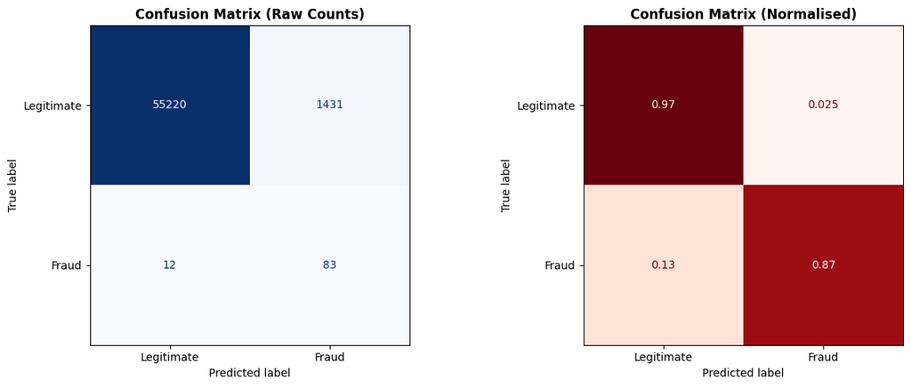

```
True Negatives  (Legitimate correctly identified): 55,220
False Positives (Legitimate incorrectly flagged):  1,431
False Negatives (Fraud missed — critical!):        12
True Positives  (Fraud correctly detected):        83

Fraud Detection Rate (Recall): 87.4%
```

```python
fig, axes = plt.subplots(1, 2, figsize=(13, 5))

cm = confusion_matrix(y_test, y_pred)
ConfusionMatrixDisplay(cm, display_labels=['Legitimate', 'Fraud']).plot(
    ax=axes[0], colorbar=False, cmap='Blues')
axes[0].set_title('Confusion Matrix (Raw Counts)', fontsize=12, fontweight='bold')

cm_norm = confusion_matrix(y_test, y_pred, normalize='true')
ConfusionMatrixDisplay(cm_norm, display_labels=['Legitimate', 'Fraud']).plot(
    ax=axes[1], colorbar=False, cmap='Reds')
axes[1].set_title('Confusion Matrix (Normalised)', fontsize=12, fontweight='bold')

plt.tight_layout()
plt.show()

tn, fp, fn, tp = cm.ravel()
print(f"True Negatives  (Legitimate correctly identified): {tn:,}")
print(f"False Positives (Legitimate incorrectly flagged):  {fp:,}")
print(f"False Negatives (Fraud missed — critical!):        {fn:,}")
print(f"True Positives  (Fraud correctly detected):        {tp:,}")
print(f"\nFraud Detection Rate (Recall): {tp/(tp+fn)*100:.1f}%")
```

**PR Curve and ROC Curve**

[figure not shown]

```python
fig, axes = plt.subplots(1, 2, figsize=(14, 5))

prec, rec, _ = precision_recall_curve(y_test, y_pred_proba)
axes[0].plot(rec, prec, color='tomato', lw=2.5,
             label=f'Random Forest (AUPRC = {test_auprc:.4f})')
axes[0].axhline(y=y_test.mean(), color='gray', linestyle='--', lw=1.5,
                label=f'Random baseline ({y_test.mean():.4f})')
axes[0].fill_between(rec, prec, alpha=0.08, color='tomato')
axes[0].set_xlabel('Recall', fontsize=12)
axes[0].set_ylabel('Precision', fontsize=12)
axes[0].set_title('Precision-Recall Curve', fontsize=13, fontweight='bold')
axes[0].legend()
axes[0].set_xlim([0, 1])
axes[0].set_ylim([0, 1.05])
axes[0].grid(alpha=0.3)

fpr, tpr, _ = roc_curve(y_test, y_pred_proba)
axes[1].plot(fpr, tpr, color='steelblue', lw=2.5,
             label=f'Random Forest (AUC = {test_roc:.4f})')
axes[1].plot([0, 1], [0, 1], 'k--', lw=1.5, label='Random baseline (0.50)')
axes[1].fill_between(fpr, tpr, alpha=0.08, color='steelblue')
axes[1].set_xlabel('False Positive Rate', fontsize=12)
axes[1].set_ylabel('True Positive Rate', fontsize=12)
axes[1].set_title('ROC Curve', fontsize=13, fontweight='bold')
axes[1].legend()
axes[1].grid(alpha=0.3)

plt.tight_layout()
plt.show()
```

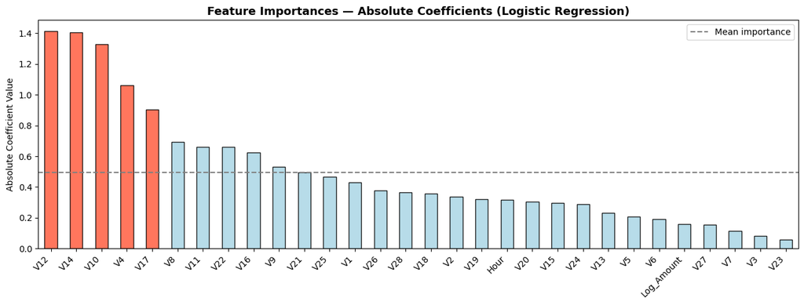

```
Top 10 features (Absolute Coefficients):
  V12             1.4144
  V14             1.4072
  V10             1.3286
  V4              1.0635
  V17             0.9052
  V8              0.6928
  V11             0.6606
  V22             0.6595
  V16             0.6229
  V9              0.5306
```

```python
feature_names = X_train_scaled.columns.tolist()
# Changed to use coefficients for Logistic Regression
importances   = pd.Series(np.abs(best_rf.coef_[0]), index=feature_names).sort_values(ascending=False)

plt.figure(figsize=(13, 5))
colors = ['tomato' if i < 5 else 'lightblue' for i in range(len(importances))]
importances.plot(kind='bar', color=colors, edgecolor='black', alpha=0.88)
# Changed title to reflect Logistic Regression coefficients
plt.title('Feature Importances — Absolute Coefficients (Logistic Regression)', fontsize=13, fontweight='bold')
plt.ylabel('Absolute Coefficient Value') # Changed y-axis label
plt.xticks(rotation=45, ha='right')
plt.axhline(importances.mean(), color='gray', linestyle='--', label='Mean importance')
plt.legend()
plt.tight_layout()
plt.show()

print("Top 10 features (Absolute Coefficients):") # Changed print statement
for feat, score in importances.head(10).items():
    print(f"  {feat:<15} {score:.4f}")
```

**Permutation Importance**

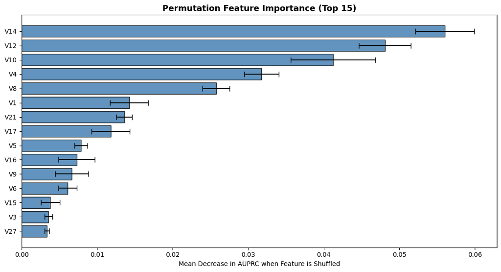

```
Top 10 by permutation importance:
Feature  Mean Drop AUPRC      Std
    V14         0.056027 0.003888
    V12         0.048086 0.003444
    V10         0.041219 0.005615
     V4         0.031757 0.002296
     V8         0.025736 0.001801
     V1         0.014234 0.002531
    V21         0.013575 0.001017
    V17         0.011800 0.002512
     V5         0.007869 0.000859
    V16         0.007302 0.002407
```

```python
perm_result = permutation_importance(
    best_rf, X_test_scaled, y_test,
    n_repeats=10,
    scoring='average_precision',
    random_state=RANDOM_STATE,
    n_jobs=-1
)

perm_df = pd.DataFrame({
    'Feature':         feature_names,
    'Mean Drop AUPRC': perm_result.importances_mean,
    'Std':             perm_result.importances_std
}).sort_values('Mean Drop AUPRC', ascending=False).head(15)

plt.figure(figsize=(11, 6))
plt.barh(perm_df['Feature'][::-1], perm_df['Mean Drop AUPRC'][::-1],
         xerr=perm_df['Std'][::-1],
         color='steelblue', edgecolor='black', alpha=0.85, capsize=4)
plt.xlabel('Mean Decrease in AUPRC when Feature is Shuffled')
plt.title('Permutation Feature Importance (Top 15)', fontsize=13, fontweight='bold')
plt.axvline(0, color='black', linewidth=0.8)
plt.tight_layout()
plt.show()

print("Top 10 by permutation importance:")
print(perm_df[['Feature', 'Mean Drop AUPRC', 'Std']].head(10).to_string(index=False))
```

# Final Discussion

## 8. Final Discussion

### 8.2 Strengths of the Solution

**1. Principled imbalance handling.** By using `class_weight='balanced'`, the loss function is adjusted during training in proportion to the class imbalance ratio — this is mathematically similar to upsampling the minority class, but it avoids the issues related to synthetic data.

**2. Pipeline without leaks.** The StandardScaler was fitted only on the training data. All hyperparameter tuning used cross-validation on the training set only. The test set was only used once — during the final evaluation — which guarantees that the metrics reported truly reflect the generalisation performance.

**3. Appropriate evaluation metrics.** For severely imbalanced binary classification, AUPRC is the suggested metric (Saito & Rehmsmeier, 2015). In contrast to ROC-AUC, AUPRC shows the real precision for the minority class at all decision thresholds.

**5. Meaningful feature engineering.** `Hour` reflects intra-day fraud patterns. By reducing distributional skew, `Log_Amount` helps improve model stability across all three candidate models.

### 8.3 Limitations

**1. PCA-anonymised features.** V1–V28 cannot be understood in business terms. Without understanding what V14 represents, stakeholders cannot act on the statement 'V14 is important.'

**2. Concept drift.** The dataset includes just two days from 2013. As fraud patterns change, a model trained on past data may lose its effectiveness without regular retraining.

**3. Absent velocity features.** In real-world scenarios, signals such as 'transactions in the last 10 minutes' or 'transaction in a new country' are some of the most predictive fraud indicators, but they are not available here.

**4. Decision threshold set in advance.** The standard threshold of 0.5 was applied. In a production environment, it's advisable to adjust this using the precision-recall curve, taking into account the cost ratio between false negatives and false positives.

### References

Bergstra, J. and Bengio, Y. (2012) 'Random Search for Hyper-Parameter Optimization', *Journal of Machine Learning Research*, 13, pp. 281–305.

Breiman, L. (2001) 'Random Forests', *Machine Learning*, 45(1), pp. 5–32.

Dal Pozzolo, A., Caelen, O., Johnson, R.A. and Bontempi, G. (2015) 'Calibrating Probability with Undersampling for Unbalanced Classification', *IEEE Symposium Series on Computational Intelligence*, pp. 159–166.

Pedregosa, F. et al. (2011) 'Scikit-learn: Machine Learning in Python', *Journal of Machine Learning Research*, 12, pp. 2825–2830.

Saito, T. and Rehmsmeier, M. (2015) 'The Precision-Recall Plot Is More Informative than the ROC Plot When Evaluating Binary Classifiers on Imbalanced Datasets', *PLOS ONE*, 10(3), e0118432.

Dataset: Creditcard.csv

URL: https://www.kaggle.com/datasets/mlg-ulb/creditcardfraud